# Probability Distribution Functions in Package qfratio

$$\DeclareMathOperator{\qfrE}{E}
\DeclareMathOperator{\qfrtr}{tr}
\DeclareMathOperator{\qfrsgn}{sgn}
\DeclareMathOperator{\qfrdiag}{diag}
\newcommand{\qfrGmf}[1]{\Gamma \! \left( #1 \right)}
\newcommand{\qfrBtf}[2]{B \! \left( #1 , #2 \right)}
\newcommand{\qfrbrc}[1]{\left[ {#1} \right]}
\newcommand{\qfrC}[2][\kappa]{ C_{#1} \! \left( #2 \right) }
\newcommand{\qfrCid}[5]{ C^{#1, #2}_{#3} \! \left( #4, #5 \right) }
\newcommand{\qfrrf}[2][k]{\left( #2 \right)_{#1}}
\newcommand{\qfrdk}[2][k]{ d_{#1} \! \left( #2 \right) }
\newcommand{\qfrdij}[3][k]{ d_{#1} \! \left( #2, #3 \right) }
\renewcommand{\det}[1]{\left\lvert #1 \right\rvert}
\newcommand{\qfrhgmf}[4]{{}_2 F_1 \left( #1 , #2 ; #3 ; #4 \right)}
\newcommand{\qfrmvnorm}[3][n]{N_{#1} \! \left( #2 , #3 \right)}
\newcommand{\qfrcchisq}[1]{\chi_{#1}^2}
\newcommand{\qfrnchisq}[2]{\chi^2 \! \left( #1 , #2 \right)}
\newcommand{\qfrBtd}[2]{\mathrm{beta} \! \left( #1 , #2 \right)}$$

Since version 1.1.0, `qfratio` ([CRAN](https://CRAN.R-project.org/package=qfratio); [GitHub](https://github.com/watanabe-j/qfratio)) has a functionality to evaluate probability density and distribution functions of a (simple) ratio of quadratic forms in normal variables. This document is to describe theoretical backgrounds and some implementation details of this functionality. See the main package vignette (`vignette("qfratio")`) for the evaluation of moments of ratios of quadratic forms.

## Symbols used

- $n$: number of variables
- $C$: (top-order) zonal and invariant polynomials of matrix arguments (Chikuse, 1980, 1987; Davis, 1980; Muirhead, 1982)
- $Q, q$: ratio of quadratic forms as a random variable $Q$ and its realized value or quantile $q$
- $F_Q(q), f_Q(q)$: (cumulative) distribution $F_Q$ and probability density $f_Q$ functions of $Q$ at $q$
- $\mathbf{x}$: $n$-variate normal random vector
- $\qfrmvnorm{\boldsymbol{\mu}}{\boldsymbol{\Sigma}}$: $n$-variate normal distribution with mean vector $\boldsymbol{\mu}$ and covariance matrix $\boldsymbol{\Sigma}$
- $\qfrnchisq{h}{\delta^2}$: noncentral chi-square distribution with $h$ degrees of freedom and noncentrality parameter $\delta^2$
- $\mathbf{A}, \mathbf{B}$: $n \times n$ argument matrices
- $\mathbf{I}_n$: $n$-dimensional identity matrix
- $\mathbf{0}_n$: $n$-variate vector of $0$’s
- $\mathbf{0}_{n \times n}$: $n \times n$ matrix of $0$’s
- $\qfrE \left( \cdot \right)$: expectation/mean
- $\qfrGmf{\cdot}$: gamma function
- $\qfrBtf{\cdot}{\cdot}$: beta function
- $\qfrrf{x}$: Pochhammer symbol, that is, $\qfrrf{x} = x (x + 1) \dots (x + k - 1)$ (with the convention $\qfrrf[0]{x} = 1$)
- $\qfrhgmf{a}{b}{c}{x}$: (Gauss) hypergeometric function, $\qfrhgmf{a}{b}{c}{x} = \sum_{k=0}^{\infty} \frac{ \qfrrf{a} \qfrrf{b} }{ \qfrrf{c} k! } x^k$
- $\mathbf{A}^T$: matrix transposition
- $\mathbf{A}^{-1}$: matrix inverse
- $\det{\mathbf{A}}$: matrix determinant
- $\qfrtr{\mathbf{A}}$: matrix trace
- $\boldsymbol{\Lambda} = \qfrdiag \left( \lambda_1 , \dots , \lambda_n \right)$: matrix of eigenvalues of $\mathbf{A} - q \mathbf{B}$
- $\mathbf{P}$: matrix of corresponding eigenvectors of $\mathbf{A} - q \mathbf{B}$
- $\boldsymbol{\Lambda}_1$, $-\boldsymbol{\Lambda}_2$: submatrices of $\boldsymbol{\Lambda}$ that has positive and negative eigenvalues
- $\boldsymbol{\nu}$: transformed mean vector, $\boldsymbol{\nu} = \mathbf{P}^T \boldsymbol{\mu}$, with $i$th element denoted by $\nu_i$
- $\mathbf{H}$: transformed $\mathbf{B}$, $\mathbf{H} = \mathbf{P}^T \mathbf{B} \mathbf{P}$, with $(i, j)$th element denoted by $h_{ij}$

Most symbols not listed here are largely restricted to individual sections.

# Theory

## Preliminaries

Consider the (simple) ratio of quadratic forms in normal variables:
$$\begin{equation}
Q = \frac{\mathbf{x}^T \mathbf{A} \mathbf{x}}
{\mathbf{x}^T \mathbf{B} \mathbf{x}},
\end{equation}$$
where $\mathbf{x} \sim \qfrmvnorm{\boldsymbol{\mu}}{\mathbf{I}_n}$. The denominator matrix $\mathbf{B}$ is assumed to be nonnegative definite, whereas $\mathbf{A}$ can be any symmetric matrix.

A more general case where $\mathbf{x} \sim \qfrmvnorm{\boldsymbol{\mu}}{\boldsymbol{\Sigma}}$ can be transformed into the above form when $\boldsymbol{\Sigma}$ is nonsingular: $\mathbf{x}_{\mathrm{new}} = \mathbf{K}^{-1} \mathbf{x}$, $\mathbf{A}_{\mathrm{new}} = \mathbf{K}^T \mathbf{A} \mathbf{K}$, etc., where $\mathbf{K}$ is an $n \times n$ matrix that satisfies $\mathbf{K} \mathbf{K}^T = \boldsymbol{\Sigma}$ (Mathai and Provost, 1992, chap. 3). When $\boldsymbol{\Sigma}$ is singular, certain conditions need to be met by the argument matrices, $\boldsymbol{\Sigma}$, and $\boldsymbol{\mu}$ for this transformation, and hence the following expressions, to be valid (Watanabe, 2023, appendix C).

Assuming $\mathbf{B}$ to be nonnegative definite, the distribution function of $Q$ is
$$\begin{equation}
\begin{aligned}
F_Q(q)
= &
\Pr \left( \frac{\mathbf{x}^T \mathbf{A} \mathbf{x}}
{\mathbf{x}^T \mathbf{B} \mathbf{x}} \leq q \right) \\
= &
\Pr \left(
\mathbf{x}^T \left( \mathbf{A} - q \mathbf{B} \right) \mathbf{x}
\leq 0
\right) ,
\end{aligned}
\end{equation}$$
so that it can be expressed as the distribution function of the quadratic form $X_q = \mathbf{x}^T \left( \mathbf{A} - q \mathbf{B} \right) \mathbf{x}$ at $0$. We are mostly concerned with such $q$ that makes $\mathbf{A} - q \mathbf{B}$ indefinite, because otherwise (i.e., when it is positive or negative (semi)definite) $F_Q(q) = 0, 1$ and $f_Q(q) = 0$.

Consider the spectral decomposition $\mathbf{A} - q \mathbf{B} = \mathbf{P} \boldsymbol{\Lambda} \mathbf{P}^T$, with an orthogonal matrix of eigenvectors $\mathbf{P}$ and a diagonal matrix of eigenvalues $\boldsymbol{\Lambda} = \qfrdiag \left( \lambda_1 , \dots , \lambda_n \right)$, and let $\mathbf{P}^T \mathbf{x} = \mathbf{y} = \left( y_1 , \dots , y_n \right)^T \sim \qfrmvnorm{\boldsymbol{\nu}}{\mathbf{I}_n}$ with $\boldsymbol{\nu} = \mathbf{P}^T \boldsymbol{\mu} = \left( \nu_1 , \dots , \nu_n \right)^T$. Then,
$$\begin{equation}
\begin{aligned}
X_q
= &
\mathbf{x}^T \left( \mathbf{A} - q \mathbf{B} \right) \mathbf{x} \\
= &
\mathbf{y}^T \boldsymbol{\Lambda} \mathbf{y} \\
= &
\sum_{i=1}^{n} \lambda_i y_i^2 .
\end{aligned}
\end{equation}$$
Obviously, $y_i^2 \sim \qfrnchisq{1}{\nu_i^2}$, a noncentral chi-square variable with $1$ degree of freedom and a noncentrality parameter $\nu_i^2$, and by construction these are independent of one another. Thus, $X_q$ is a weighted sum of independent chi-square variables, and the problem boils down to evaluation of the distribution of this quantity.

## Series expression

Explicit formulae for the distribution and density function of $Q$ have been worked out by Hillier (2001) and Forchini (2002, 2005). These typically involve infinite series of the top-order zonal and invariant polynomials of matrix arguments. The zonal polynomials are certain homogeneous polynomials of eigenvalues of a symmetric matrix which extend powers of scalars into symmetric matrices (e.g., Muirhead, 1982). The invariant polynomials are further extension of the zonal polynomials to multiple matrix arguments (see Chikuse, 1980, 1987; Davis, 1980). These polynomials are used to integrate out components of rotation from a function of random matrices.

### Distribution function

Forchini (2002, 2005) derived explicit expressions of $F_Q$ using the top-order zonal and invariant polynomials.

Let $\boldsymbol{\Lambda}$ from above be arranged and partitioned such that
$$\begin{equation}
\boldsymbol{\Lambda} =
\left( \begin{matrix}
\boldsymbol{\Lambda}_1(q) & \mathbf{0}_{n_{+} \times n_{-}}
& \mathbf{0}_{n_{+} \times (n - n_{+} - n_{-})} \\
\mathbf{0}_{n_{-} \times n_{+}} & -
\boldsymbol{\Lambda}_2(q) & \mathbf{0}_{n_{-} \times (n - n_{+} -
n_{-})} \\
\mathbf{0}_{(n - n_{+} - n_{-}) \times n_{+}} &
\mathbf{0}_{(n - n_{+} - n_{-}) \times n_{-}} & \mathbf{0}_{(n -
n_{+} - n_{-}) \times (n - n_{+} - n_{-})}
\end{matrix}\right),
\end{equation}$$
where $\boldsymbol{\Lambda}_1(q)$ and $- \boldsymbol{\Lambda}_2(q)$ are $n_{+}$- and $n_{-}$-dimensional diagonal matrices of positive and negative eigenvalues of $\mathbf{A} - q \mathbf{B}$, respectively. By denoting
$$\begin{equation}
\begin{aligned}
\boldsymbol{\nu}
= &
\left( \begin{matrix}
\boldsymbol{\nu}_1 \\
\boldsymbol{\nu}_2 \\
\boldsymbol{\nu}_3
\end{matrix}\right) , \\
{\boldsymbol{\Lambda}_1^*}^{-1}
= & \left( \qfrtr \left( {\boldsymbol{\Lambda}_1}^{-1} \right)
+ \qfrtr \left( {\boldsymbol{\Lambda}_2}^{-1} \right) \right)^{-1}
{\boldsymbol{\Lambda}_1}^{-1}, \\
{\boldsymbol{\Lambda}_2^*}^{-1}
= & \left( \qfrtr \left( {\boldsymbol{\Lambda}_1}^{-1} \right)
+ \qfrtr \left( {\boldsymbol{\Lambda}_2}^{-1} \right) \right)^{-1}
{\boldsymbol{\Lambda}_2}^{-1},
\end{aligned}
\end{equation}$$
with the partition of $\boldsymbol{\nu}$ corresponding to that of the rows of $\boldsymbol{\Lambda}$ above, the expression of Forchini (2005) is, after correcting some errors,
$$\begin{equation}
\begin{aligned}
F_Q(q) = &
\frac{
\qfrGmf{ \frac{n_{+} + n_{-}}{2} }
\exp \left[ - \frac{1}{2} \left( \boldsymbol{\nu}_1^T
\boldsymbol{\nu}_1 + \boldsymbol{\nu}_2^T \boldsymbol{\nu}_2
\right) \right]
}{ \qfrGmf{ \frac{n_{+}}{2} + 1 } \qfrGmf{ \frac{n_{-}}{2} }
\det{\boldsymbol{\Lambda}_1^*}^{\frac{1}{2}}
\det{\boldsymbol{\Lambda}_2^*}^{\frac{1}{2}} } \\
& \cdot
\sum_{i_1 = 0}^{\infty} \sum_{j_1 = 0}^{\infty} \sum_{i_2 =
0}^{\infty} \sum_{j_2 = 0}^{\infty}
\frac{
\qfrrf[i_1 + j_1 + i_2 + j_2]{\frac{n_{+} + n_{-}}{2}}
\qfrrf[i_1 + j_1]{\frac{1}{2}} \qfrrf[i_2 + j_2]{\frac{1}{2}}
}{
\qfrrf[i_1 + j_1]{\frac{n_{+}}{2} + 1}
\qfrrf[i_2 + j_2]{\frac{n_{-}}{2}}
\qfrrf[j_1]{\frac{1}{2}} \qfrrf[j_2]{\frac{1}{2}}
i_1! j_1! i_2! j_2!
} \\
& \quad \cdot
\qfrCid{\qfrbrc{i_1}}{\qfrbrc{j_1}}{\qfrbrc{i_1 + j_1}}{ \qfrtr
\left( {\boldsymbol{\Lambda}_1^*}^{-1} \right) \mathbf{I}_{n_{+}} -
{\boldsymbol{\Lambda}_1^*}^{-1} }{ \frac{1}{2}
{\boldsymbol{\Lambda}_1^*}^{-\frac{1}{2}} \boldsymbol{\nu}_1
\boldsymbol{\nu}_1^T {\boldsymbol{\Lambda}_1^*}^{-\frac{1}{2}} } \\
& \quad \cdot
\qfrCid{\qfrbrc{i_2}}{\qfrbrc{j_2}}{\qfrbrc{i_2 + j_2}}{ \qfrtr
\left( {\boldsymbol{\Lambda}_2^*}^{-1} \right) \mathbf{I}_{n_{-}} -
{\boldsymbol{\Lambda}_2^*}^{-1} }{ \frac{1}{2}
{\boldsymbol{\Lambda}_2^*}^{-\frac{1}{2}} \boldsymbol{\nu}_2
\boldsymbol{\nu}_2^T {\boldsymbol{\Lambda}_2^*}^{-\frac{1}{2}} } \\
& \quad \cdot
{}_2 F_1 \left(\frac{n_{+} + n_{-}}{2} + i_1 + j_1 + i_2 + j_2, 1;
\frac{n_{+}}{2} + i_1 + j_1 + 1; \qfrtr \left(
{\boldsymbol{\Lambda}_1^*}^{-1} \right) \right)
,
\end{aligned}
\end{equation}$$
where $\qfrCid{\qfrbrc{k_1}}{\qfrbrc{k_2}}{\qfrbrc{k_1 + k_2}}{ \cdot }{ \cdot }$ are the top-order invariant polynomials of $(k_1, k_2)$-th degree (see above for other notations).

In the central case ($\boldsymbol{\mu} = \mathbf{0}_n$), the above expression simplifies into (Forchini, 2002)
$$\begin{equation}
\begin{aligned}
F_Q(q) = &
\frac{
\qfrGmf{ \frac{n_{+} + n_{-}}{2} }
}{ \qfrGmf{ \frac{n_{+}}{2} + 1 } \qfrGmf{ \frac{n_{-}}{2} }
\det{\boldsymbol{\Lambda}_1^*}^{\frac{1}{2}}
\det{\boldsymbol{\Lambda}_2^*}^{\frac{1}{2}} } \\
& \cdot
\sum_{i_1 = 0}^{\infty} \sum_{i_2 = 0}^{\infty}
\frac{
\qfrrf[i_1 + i_2]{\frac{n_{+} + n_{-}}{2}}
\qfrrf[i_1]{\frac{1}{2}} \qfrrf[i_2]{\frac{1}{2}}
}{
\qfrrf[i_1]{\frac{n_{+}}{2} + 1}
\qfrrf[i_2]{\frac{n_{-}}{2}}
i_1! i_2!
} \\
& \quad \cdot
\qfrC[\qfrbrc{i_1}]{ \qfrtr \left( {\boldsymbol{\Lambda}_1^*}^{-1}
\right) \mathbf{I}_{n_{+}} - {\boldsymbol{\Lambda}_1^*}^{-1} }
\qfrC[\qfrbrc{i_2}]{ \qfrtr \left( {\boldsymbol{\Lambda}_2^*}^{-1}
\right) \mathbf{I}_{n_{-}} - {\boldsymbol{\Lambda}_2^*}^{-1} } \\
& \quad \cdot
{}_2 F_1 \left(\frac{n_{+} + n_{-}}{2} + i_1 + i_2, 1;
\frac{n_{+}}{2} + i_1 + 1; \qfrtr \left( {\boldsymbol{\Lambda}_1^*}^{-1}
\right) \right)
,
\end{aligned}
\end{equation}$$
where $\qfrC[\qfrbrc{k}]{ \cdot }$ are the top-order zonal polynomials of $k$th degree.

These expressions can be numerically evaluated by truncating the infinite series at certain higher-order terms ($i_1 + j_1 + i_2 + j_2 = m$, say), and by using a recursive algorithm to calculate
$$\begin{equation}
\qfrdij[k_1, k_s]{ \mathbf{A}_1 }{ \mathbf{A}_2 } =
\frac{ \qfrrf[k_1 + k_2]{\frac{1}{2}} }{ k_1 ! k_2 !}
\qfrCid{\qfrbrc{k_1}}{\qfrbrc{k_2}}{\qfrbrc{k_1 + k_2}}{ \mathbf{A}_1
}{ \mathbf{A}_2 }
\end{equation}$$
by Hillier et al. (2009, 2014) (see also the main vignette `qfratio`). The present package implements this algorithm in `pqfr(..., method = "forchini")` (see below).

The distribution function has points of nonanalyticity around the eigenvalues of $\mathbf{B}^{-1} \mathbf{A}$ (assuming $\mathbf{B}^{-1}$ is invertible) (Forchini, 2002). Practically speaking, around these points, the series expression can be slow to converge and evaluation of the hypergeometric function can fail because the argument $\qfrtr \left( {\boldsymbol{\Lambda}_1^*}^{-1} \right)$ becomes very close to `1`. Otherwise, the series expression can be evaluated with high accuracy, although the computational cost of the recursive calculations can be substantial in large problems.

### Density function

Apparently, the literature has an explicit expression for the density of $Q$ only for the simple condition when $\mathbf{B} = \mathbf{I}_n$ and $\boldsymbol{\mu} = \mathbf{0}_n$. In this case, the distribution of $Q$ does not depend on the norm of $\mathbf{x}$, so any spherically symmetric distribution of $\mathbf{x}$ yields the same distribution of $Q$ (Hillier, 2001).

Let $\eta_1 > \dots > \eta_s$ be $s$ distinct eigenvalues of $\mathbf{A}$, and $n_1 , \dots , n_s$ be the corresponding degrees of multiplicity ($\sum_{i=1}^{s} n_i = n$). Consider the transformed variable $V = \frac{Q - \eta_s}{\eta_1 - Q}$ and parameters $\psi_i = \frac{\eta_i - \eta_s}{\eta_1 - \eta_i}$ for $i = 2, \dots s - 1$, assuming $s > 2$ (see below for the case when $s = 2$). The density of $V$ has different functional forms across its domain (from Hillier, 2001, lemmas 3 and 4):
$$\begin{equation}
\begin{aligned}
f_V (v) = &
\left[ \qfrBtf{ \frac{p_r}{2} }{ \frac{n - p_r}{2} } \right]^{-1}
\left[ \prod_{i=2}^{r+1} \psi_i^{- \frac{n_i}{2}} \right]
\left[ \prod_{i=2}^{s-1} (1 + \psi_i)^{\frac{n_i}{2}} \right]
v^{\frac{p_r}{2} - 1} (1 + v)^{- \frac{n}{2}}
& \\ & \quad \cdot
\sum_{j=0}^{\infty} \sum_{k=0}^{\infty}
c_r (j, k)
\frac{ \qfrrf[j]{\frac{1}{2}} \qfrrf[k]{\frac{1}{2}} }{ j! k! }
\qfrC[\qfrbrc{j}]{v \mathbf{D}_{r}}
\qfrC[\qfrbrc{k}]{\left( v \mathbf{D}_{r+1} \right)^{-1}} ,
&
\psi_{r + 2} < v < \psi_{r + 1}, \atop r = 1, \dots , s - 2 ,
\\
f_V (v) = &
\left[ \qfrBtf{ \frac{n_s}{2} }{ \frac{n - n_s}{2} } \right]^{-1}
\left[ \prod_{i=2}^{s-1} \left( \frac{1 + \psi_i}{\psi_i}
\right)^{\frac{n_i}{2}} \right]
v^{\frac{n - n_s}{2} - 1} (1 + v)^{- \frac{n}{2}}
& \\ & \quad \cdot
\sum_{k=0}^{\infty}
\frac{ \qfrrf{-\frac{n_s}{2} + 1} \qfrrf{\frac{1}{2}} }{
\qfrrf{\frac{n - n_s}{2} + 1} k! }
\qfrC[\qfrbrc{k}]{v \mathbf{D}} ,
& 0 < v < \psi_{s - 1} , \\
f_V (v) = &
\left[ \qfrBtf{ \frac{n_1}{2} }{ \frac{n - n_1}{2} } \right]^{-1}
\left[ \prod_{i=2}^{s-1} \left( 1 + \psi_i \right)^{\frac{n_i}{2}}
\right]
v^{\frac{n_1}{2} - 1} (1 + v)^{- \frac{n}{2}}
& \\ & \quad \cdot
\sum_{k=0}^{\infty}
\frac{ \qfrrf{-\frac{n_1}{2} + 1} \qfrrf{\frac{1}{2}} }{
\qfrrf{\frac{n - n_1}{2} + 1} k! }
\qfrC[\qfrbrc{k}]{\left( v \mathbf{D} \right)^{-1}} ,
& \psi_{2} < v ,
\end{aligned}
\end{equation}$$
where $p_r = \sum_{i=1}^{r+1} n_i$, $\mathbf{D}_{r} = \qfrdiag \left( \psi_{2}^{-1} \mathbf{I}_{n_{2}} , \dots , \psi_{r+1}^{-1} \mathbf{I}_{n_{r+1}} \right)$, $\mathbf{D}_{r+1} = \qfrdiag \left( \psi_{r+2}^{-1} \mathbf{I}_{n_{r+2}} , \dots , \psi_{s-1}^{-1} \mathbf{I}_{n_{s-1}} \right)$, $\mathbf{D} = \qfrdiag \left( \psi_{2}^{-1} \mathbf{I}_{n_{2}} , \dots , \psi_{s-1}^{-1} \mathbf{I}_{n_{s-1}} \right)$, and $c_r (j, k)$ are the coefficients defined as
$$\begin{equation}
c_r (j, k) =
\begin{cases}
1 , & j = k , \\
\qfrrf[k-j]{ - \frac{p_r}{2} + 1} \large{/} \qfrrf[k-j]{ \frac{n
- p_r}{2} } , & j < k , \\
\qfrrf[j-k]{ - \frac{n - p_r}{2} + 1} \large{/} \qfrrf[j-k]{
\frac{p_r}{2} } , & j > k . \\
\end{cases}
\end{equation}$$
$c_r (j, k)$ can be $0$ when $p_r$ or $n - p_r$ is even, so that some terms in the above series disappear. Otherwise (whenever $c_r (j, k) \neq 0$), it is possible to write
$$\begin{equation}
c_r (j, k) =
(-1)^{j-k}
\frac{\qfrGmf{\frac{p_r}{2}} \qfrGmf{\frac{n - p_r}{2}}}{
\qfrGmf{\frac{p_r}{2} + j - k} \qfrGmf{\frac{n - p_r}{2} + k -
j}
} ,
\end{equation}$$
to simplify calculation. The density is undefined at $v = \psi_{i}$ ($q = \eta_i$) for any $i$.

From one of the above expressions, $f_Q(q)$ can be obtained as
$$\begin{equation}
\begin{aligned}
f_Q (q) = &
f_V (v)
\cdot
\left| \frac{\mathrm{d} q}{\mathrm{d} v} \right|
\\
= &
f_V \left( \frac{q - \eta_s}{\eta_1 - q} \right)
\cdot
\frac{\eta_1 - \eta_s}{\left( \eta_1 - q \right)^2} .
\end{aligned}
\end{equation}$$
It is seen that, when $s = 2$ (i.e., there are only two distinct eigenvalues), the above becomes
$$\begin{equation}
\begin{aligned}
f_Q (q) = &
\left[ \qfrBtf{ \frac{n_1}{2} }{ \frac{n_s}{2} } \right]^{-1}
\frac{
\left( q - \eta_s \right)^{\frac{n_1}{2} - 1}
\left( \eta_1 - q \right)^{\frac{n_s}{2} - 1}
}{
\left( \eta_1 - \eta_s \right)^{\frac{n_1 + n_s}{2} - 1}
} ,
\end{aligned}
\end{equation}$$
which is the density of the (scaled) beta distribution in the interval $\left[ \eta_s , \eta_1 \right]$ with the parameters $n_1 / 2$ and $n_s / 2$. This result is expected from the basic relationship between the chi-square and beta distributions, i.e., $\qfrcchisq{n_1} / \left( \qfrcchisq{n_1} + \qfrcchisq{n_s} \right) = b \sim \qfrBtd{n_1 / 2}{n_s / 2}$, a standard beta distribution in $[0, 1]$, with $\qfrcchisq{n_i}$ being independent chi-square variables; $Q = \left( \eta_1 \qfrcchisq{n_1} + \eta_s \qfrcchisq{n_s} \right) / \left( \qfrcchisq{n_1} + \qfrcchisq{n_s} \right) = \eta_1 b + \eta_s \left( 1 - b \right) = \left( \eta_1 - \eta_s \right) b + \eta_s$.

As for the above series expression of $F_Q$, these expressions can be evaluated by taking a partial sum of the series and using the recursive algorithm for $d$. `dqfr(..., method = "hillier")` implements this algorithm (see below). This is reasonably quick and accurate in small problems, but the computational cost can be substantial in large problems.

## Numerical inversion

A popular way to numerically evaluate the distribution function of $Q$ is to use the inversion formula of the characteristic function (e.g., Stuart and Ord, 1994, chap. 4).

### Distribution function

From the famous formula of Imhof (1961) on the distribution of $X_q$,
$$\begin{equation}
F_Q(q)
= \frac{1}{2} -
\frac{1}{\pi}
\int_{0}^{\infty} \frac{\sin \beta (u)}{u \gamma (u)} \, \mathrm{d}u
,
\end{equation}$$
where
$$\begin{equation}
\begin{aligned}
\beta (u)
= &
\frac{1}{2} \sum_{i=1}^{n}
\left[
\arctan \left( u \lambda_i \right)
+ \frac{\nu_i^2 u \lambda_i}{1 + u^2 \lambda_i^2}
\right] , \\
\gamma (u)
= &
\prod_{i=1}^{n} \left( 1 + u^2 \lambda_i^2 \right)^{\frac{1}{4}}
\exp \left[ \frac{1}{2}
\sum_{i=1}^{n} \frac{\nu_i^2 u^2 \lambda_i^2}{1 + u^2
\lambda_i^2}
\right] .
\end{aligned}
\end{equation}$$

The above integral can be evaluated by using a regular numerical evaluation algorithm for infinite intervals. Alternatively, it can be evaluated by the trapezoidal integration algorithm of Davies (1973, 1980) which explicitly controls the numerical errors involved. The package `CompQuadForm` implements these methods in the function `imhof()` and `davies()`, respectively (strictly speaking, these are for $1 - F_Q$ as per Imhof’s original result). The present package utilizes those functions via `pqfr(..., method = "imhof", use_cpp = FALSE)` and `pqfr(..., method = "davies")`, respectively (see below). For the former method, the present package also has its own `C++` implementation used via `pqfr(..., method = "imhof", use_cpp = TRUE)` (default). The numerical inversion can be evaluated fairly quickly on modern computers, and the accuracy will be sufficient for most practical purposes with slight error in numerical integration.

### Density function

The density can be evaluated by numerical inversion of the characteristic function using Geary’s formula (Geary, 1944; Stuart and Ord, 1994, sec. 11.10). Broda and Paolella (2009) demonstrated that
$$\begin{equation}
f_Q(q)
= \frac{1}{\pi}
\int_{0}^{\infty}
\frac{\rho (u) \cos \beta (u) - u \delta (u) \sin \beta (u)}{2
\gamma (u)}
\, \mathrm{d}u ,
\end{equation}$$
where, along with $\beta$ and $\gamma$ defined above,
$$\begin{equation}
\begin{aligned}
\rho (u)
= &
\sum_{i=1}^{n} \frac{h_{ii}}{1 + u^2 \lambda_i^2}
+ \sum_{i=1}^{n} \sum_{j=1}^{n}
\frac{ \nu_i \nu_j h_{ij} \left( 1 - u^2 \lambda_ i \lambda_j
\right) }{
\left( 1 + u^2 \lambda_i^2 \right) \left( 1 + u^2 \lambda_j^2
\right)}
\\
= &
\qfrtr \left( \mathbf{H} \mathbf{F}^{-1} \right)
+
\boldsymbol{\nu}^T \mathbf{F}^{-1}
\left(
\mathbf{H} - u^2 \boldsymbol{\Lambda} \mathbf{H}
\boldsymbol{\Lambda}
\right)
\mathbf{F}^{-1} \boldsymbol{\nu} , \\
\delta (u)
= &
\sum_{i=1}^{n} \frac{ h_{ii} \lambda_i }{1 + u^2 \lambda_i^2}
+ \sum_{i=1}^{n} \sum_{j=1}^{n}
\frac{ 2 \nu_i \nu_j h_{ij} \lambda_i }{
\left( 1 + u^2 \lambda_i^2 \right) \left( 1 + u^2 \lambda_j^2
\right)}
\\
= &
\qfrtr \left( \mathbf{H} \boldsymbol{\Lambda} \mathbf{F}^{-1}
\right)
+ 2
\boldsymbol{\nu}^T \mathbf{F}^{-1} \mathbf{H} \boldsymbol{\Lambda}
\mathbf{F}^{-1} \boldsymbol{\nu} , \\
\end{aligned}
\end{equation}$$
with $\mathbf{H} = \mathbf{P}^T \mathbf{B} \mathbf{P} = \left( h_{ij} \right)$ and $\mathbf{F} = \mathbf{I}_n + u^2 \boldsymbol{\Lambda}^2$.

The above expression can be evaluated with a regular numerical integration algorithm, and is implemented in `dqfr(..., method = "broda")` (see below).

## Saddlepoint approximation

Saddlepoint approximation (Butler, 2007; Paolella, 2007, chap. 5) provides an alternative way to evaluate (or approximate) $F_Q$ and $f_Q$.

Let $M_{X_q}(s)$ be the moment generating function of $X_q$,
$$\begin{equation}
M_{X_q}(s)
=
\prod_{i=1}^{n} \left( 1 - 2 s \lambda_i^2 \right)^{-\frac{1}{2}}
\exp \left[ s
\sum_{i=1}^{n} \frac{\nu_i^2 \lambda_i}{1 - 2 s \lambda_i^2}
\right] .
\end{equation}$$
Also, let $K_{X_q}(s) = \log M_{X_q}(s)$ be the corresponding cumulant generating function. These are convergent within the interval $1 / 2 \lambda_n < s < 1 / 2 \lambda_1$, where $\lambda_1$ and $\lambda_n$ are the largest and smallest of the eigenvalues (which are positive and negative, respectively; see above).

For $X_q$, the saddlepoint root $\hat{s}$ is defined as the unique root of
$$\begin{equation}
0 = K_{X_q}' \left( \hat{s} \right) =
\sum_{i=1}^{n}
\left[
\frac{\lambda_i}{1 - 2 \hat{s} \lambda_i^2} +
\frac{\nu_i^2 \lambda_i}{\left( 1 - 2 \hat{s} \lambda_i^2
\right)^2}
\right] ,
\end{equation}$$
and is found numerically within the above interval.

### Distribution function

A first-order saddlepoint approximation formula for the distribution function $F_Q$ is (Butler and Paolella, 2007, 2008):
$$\begin{equation}
\widehat{\Pr{}}_1 (Q < q)
=
\begin{cases}
\Phi \left( \hat{w} \right) +
\phi \left( \hat{w} \right) \left[ \hat{w}^{-1} - \hat{u}^{-1}
\right] ,
& \text{if } \qfrE \left( X_q \right) \neq 0 , \\
\frac{1}{2} + \frac{ K_{X_q}'''(0) }{ 6 \sqrt{2
\pi} K_{X_q}''(0)^{3/2} } ,
& \text{if } \qfrE \left( X_q \right) = 0 , \\
\end{cases}
\end{equation}$$
where $\Phi \left( \cdot \right)$ and $\phi \left( \cdot \right)$ are the distribution and density functions, respectively, of the standard normal distribution, and
$$\begin{equation}
\begin{aligned}
\hat{w} = & \qfrsgn \left(\hat{s}\right) \sqrt{-2 K_{X_q}
(\hat{s})} , \\
\hat{u} = & \hat{s} \sqrt{K_{X_q}'' (\hat{s})} .
\end{aligned}
\end{equation}$$
The condition $\qfrE \left( X_q \right) = 0$ is equivalent to $\hat{s} = 0$, because of the elementary property of the cumulant generating function $\qfrE \left( X_q \right) = K_{X_q}' \left( 0 \right)$. Higher-order derivatives of $K_{X_q}$ are (see also Paolella, 2007, chap. 10)
$$\begin{equation}
\begin{aligned}
K_{X_q}'' \left( s \right)
= &
2 \sum_{i=1}^{n}
\frac{ \lambda_i^2 }{\left( 1 - 2 s \lambda_i \right)^2}
\left(1 + \frac{ 2 \nu_i^2 }{1 - 2 s \lambda_i} \right) , \\
K_{X_q}''' \left( s \right)
= &
8 \sum_{i=1}^{n}
\frac{ \lambda_i^3 }{\left( 1 - 2 s \lambda_i \right)^3}
\left(1 + \frac{ 3 \nu_i^2 }{1 - 2 s \lambda_i} \right) , \\
K_{X_q}^{(4)} \left( s \right)
= &
48 \sum_{i=1}^{n}
\frac{ \lambda_i^4 }{\left( 1 - 2 s \lambda_i \right)^4}
\left(1 + \frac{ 4 \nu_i^2 }{1 - 2 s \lambda_i} \right) .
\end{aligned}
\end{equation}$$

A more accurate second-order approximation is (Butler and Paolella, 2007)
$$\begin{equation}
\widehat{\Pr{}}_2 (Q < q)
=
\widehat{\Pr{}}_1 (Q < q) - \phi \left( \hat{w} \right)
\left[
\hat{u}^{-1}
\left( \frac{\hat{\kappa}_4}{8} - \frac{5}{24} \hat{\kappa}_3^2
\right)
- \hat{u}^{-3}
- \frac{ \hat{\kappa}_3^2 }{ 2 \hat{u}^2 }
+ \hat{w}^{-3}
\right] ,
\quad \qfrE \left( X_q \right) \neq 0,
\end{equation}$$
where $\hat{\kappa}_j = K_{X_q}^{(j)} \left( \hat{s} \right) / K_{X_q}'' \left( \hat{s} \right)^{j/2}$.

Evaluation of saddlepoint approximation is fairly quick, with the only potential complexity arising from the numerical root-finding. Empirically, the accuracy of this approximation seems to improve for large problems. This is expected since the distribution of $X_q$ as a weighted sum approaches normality as $n$ increases.

`pqfr(..., method = "butler")` implements this saddlepoint approximation. The second-order approximation is used by default (`order_spa = 2`) (see below).

## Density function

A first-order saddlepoint approximation for the density function $f_Q$ is (Butler and Paolella, 2007, 2008)
$$\begin{equation}
\hat{f_1}(q)
=
\frac{
J_q \left( \hat{s} \right)
}{
\sqrt{ 2 \pi K_{X_q}'' \left( \hat{s} \right) }
}
M_{X_q} \left( \hat{s} \right) ,
\end{equation}$$
where $\hat{s}$ is the same saddlepoint root used above, and
$$\begin{equation}
J_q \left( s \right)
=
\qfrtr \left(
\boldsymbol{\Xi}^{-1} \mathbf{H}
\right)
+ \boldsymbol{\nu}^T \boldsymbol{\Xi}^{-1}
\mathbf{H}
\boldsymbol{\Xi}^{-1} \boldsymbol{\nu}
,
\end{equation}$$
using notations defined above and $\boldsymbol{\Xi} = \mathbf{I}_n - 2 s \boldsymbol{\Lambda}$.

A second-order approximation is (Butler and Paolella, 2007)
$$\begin{equation}
\hat{f_2}(q)
=
\hat{f_1}(q) (1 + O) ,
\end{equation}$$
where
$$\begin{equation}
O
=
\left(
\frac{\hat{\kappa}_4}{8} - \frac{5}{24} \hat{\kappa}_3^2
\right)
+ \frac{
J_q' \left( \hat{s} \right) \hat{\kappa}_3
}{
2 J_q \left( \hat{s} \right) \sqrt{K_q'' \left( \hat{s}
\right)}
}
- \frac{
J_q'' \left( \hat{s} \right)
}{
2 J_q \left( \hat{s} \right) K_q'' \left( \hat{s} \right)
}
,
\end{equation}$$
with
$$\begin{equation}
\begin{aligned}
J_q' \left( s \right)
= &
2 \qfrtr \left(
\boldsymbol{\Xi}^{-1} \boldsymbol{\Lambda}
\boldsymbol{\Xi}^{-1} \mathbf{H}
\right)
+ 4 \boldsymbol{\nu}^T \boldsymbol{\Xi}^{-1}
\boldsymbol{\Lambda} \boldsymbol{\Xi}^{-1}
\mathbf{H}
\boldsymbol{\Xi}^{-1} \boldsymbol{\nu}
\\
= &
2 \qfrtr \left(
\boldsymbol{\Xi}^{-2} \boldsymbol{\Lambda} \mathbf{H}
\right)
+ 4 \boldsymbol{\nu}^T \boldsymbol{\Xi}^{-2}
\boldsymbol{\Lambda} \mathbf{H}
\boldsymbol{\Xi}^{-1} \boldsymbol{\nu}
, \\
J_q'' \left( s \right)
= &
8 \qfrtr \left(
\boldsymbol{\Xi}^{-3} \boldsymbol{\Lambda}^{2} \mathbf{H}
\right)
+ 16 \boldsymbol{\nu}^T \boldsymbol{\Xi}^{-3}
\boldsymbol{\Lambda}^{2} \mathbf{H}
\boldsymbol{\Xi}^{-1} \boldsymbol{\nu}
+ 8 \boldsymbol{\nu}^T \boldsymbol{\Xi}^{-2}
\boldsymbol{\Lambda} \mathbf{H}
\boldsymbol{\Lambda}
\boldsymbol{\Xi}^{-2} \boldsymbol{\nu}
,
\end{aligned}
\end{equation}$$
($\boldsymbol{\Xi}^{-1}$ and $\boldsymbol{\Lambda}$ commute since these are diagonal matrices).

`dqfr(..., method = "butler")` implements this saddlepoint approximation in a very similar way to `pqfr(..., method = "butler")` (see below).

# Implementation details

## Exported functions

The above expressions for the distribution and density functions are implemented in `pqfr()` and `dqfr()`, which are defined as:

```r
pqfr <- function(quantile, A, B, p = 1, mu = rep.int(0, n), Sigma = diag(n),
                 lower.tail = TRUE, log.p = FALSE,
                 method = c("imhof", "davies", "forchini", "butler"),
                 trim_values = TRUE, return_abserr_attr = FALSE, m = 100L,
                 tol_zero = .Machine$double.eps * 100,
                 tol_sing = tol_zero, ...) { ... }
dqfr <- function(quantile, A, B, p = 1, mu = rep.int(0, n), Sigma = diag(n),
                 log = FALSE, method = c("broda", "hillier", "butler"),
                 trim_values = TRUE, normalize_spa = FALSE,
                 return_abserr_attr = FALSE, m = 100L,
                 tol_zero = .Machine$double.eps * 100,
                 tol_sing = tol_zero, ...) { ... }
```

The basic usage is similar to that of regular probability distribution functions like `stats::pnorm()`, just with many optional arguments to specify evaluation methods and behaviors at edge cases. These functions are (pseudo-)vectorized with respect to `quantile` (a vector of $q$), using `sapply()`. Log-transformed $p$-values or densities can be obtained by turning `log.p = TRUE` or `log = TRUE`, but these are just ad-hoc transformations of the results so are not supposed to provide as much numerical accuracy as in regular probability distribution functions.

There is also `qqfr()` for the corresponding quantile function, which is defined as:

```r
qqfr <- function(probability, A, B, p = 1, mu = rep.int(0, n), Sigma = diag(n),
                 lower.tail = TRUE, log.p = FALSE, trim_values = FALSE,
                 return_abserr_attr = FALSE, stop_on_error = FALSE, m = 100L,
                 tol_zero = .Machine$double.eps * 100,
                 tol_sing = tol_zero, epsabs_q = .Machine$double.eps ^ (1/2),
                 maxiter_q = 5000, ...) { ... }
```

This function is not based on any explicit inverse function, but does numerical root-finding using `stats::uniroot()`, internally calling `pqfr()`; i.e., by searching the root `q` of `pqfr(q, ...) - probability = 0`.

Internally, these functions first check basic argument structures, and, if `Sigma` is specified, transform the arguments `A`, `B`, and `mu` and call themselves recursively with new arguments.

### Choosing a method

The evaluation method is specified by the argument `method` in these functions (by default, both functions choose a numerical inversion method). According to the choice, the actual calculations are done in one of the *internal* functions described below. Direct use of the internal functions are *not* recommended. These internal functions only accept a length-one `quantile`. To reduce computational time, they do not check argument structures or accommodate `Sigma`.

```r
## Choice from alternative methods
A <- diag(1:3)
pqfr(1.5, A, method = "imhof")    # default
```

```
#> [1] 0.1978686
```

```r
pqfr(1.5, A, method = "davies")   # similar
```

```
#> [1] 0.1979048
```

```r
pqfr(1.5, A, method = "forchini") # series
```

```
#> [1] 0.1978686
```

```r
pqfr(1.5, A, method = "butler")   # spa
```

```
#> [1] 0.1897189
```

```r
dqfr(1.5, A, method = "broda")    # default
```

```
#> [1] 0.4506431
```

```r
dqfr(1.5, A, method = "hillier")  # series
```

```
#> [1] 0.4506431
```

```r
dqfr(1.5, A, method = "butler")   # spa
```

```
#> [1] 0.4523631
```

```r
## Not recommended; for diagnostic use only
qfratio:::pqfr_imhof(1.5, A)
```

```
#> $p
#> [1] 0.1978686
#>
#> $abserr
#> [1] 2.031334e-09
```

```r
qfratio:::pqfr_A1B1(1.5, A, m = 9, check_convergence = FALSE)
```

```
#> $p
#> [1] 0.1978641
#>
#> $terms
#>  [1] 1.495393e-01 3.427348e-02 9.516357e-03 2.974620e-03 1.002253e-03
#>  [6] 3.544878e-04 1.295434e-04 4.844575e-05 1.842967e-05 7.103869e-06
```

```r
## This is okay
x <- c(1.5, 2.5, 3.5)
pqfr(x, A)
```

```
#> [1] 0.1978686 0.8021314 1.0000000
```

```r
## This is not
qfratio:::pqfr_imhof(x, A)
```

```
#> Error in qfratio:::pqfr_imhof(x, A): In pqfr_imhof, quantile must be length-one
```

### Use with `ks.test()`

In principle, `pqfr()` is compatible with `stats:::ks.test()`, but care must be exercised as evaluation result may involve non-trivial error. It is recommended to inspect error bounds beforehand, using `pqfr(..., method = "imhof", return_abserr_attr = TRUE)`. In addition, the argument `B` is pre-occupied by the same-named argument in `ks.test()`, so it cannot be passed via `...`; this means that a typical syntax with non-default `B` should be something like `ks.test(x, function(q) pqfr(q, A, B, ...))` rather than `ks.test(x, pqfr, A = A, B = B, ...))`. For example,

```r
## Small Monte Carlo sample
A <- diag(1:3)
B <- diag(sqrt(1:3))
x <- rqfr(10, A, B)

## Calculate p-values
pseq <- pqfr(x, A, B, return_abserr_attr = TRUE)

## Maximum error when evaluated at x;
## looks small enough
max(attr(pseq, "abserr"))
```

```
#> [1] 8.318564e-07
```

```r
## Correct syntax, expected outcome
## \(q) syntax could also be used in recent versions of R
ks.test(x, function(q) pqfr(q, A, B))
```

```
#>
#>  Exact one-sample Kolmogorov-Smirnov test
#>
#> data:  x
#> D = 0.29324, p-value = 0.2946
#> alternative hypothesis: two-sided
```

rather than

```r
## Incorrect; no error/warning because
## B is passed to ks.test rather than to pqfr
ks.test(x, pqfr, A = A, B = B)
```

```
#>
#>  Exact one-sample Kolmogorov-Smirnov test
#>
#> data:  x
#> D = 0.78335, p-value = 5.182e-07
#> alternative hypothesis: two-sided
```

## Series expressions

```r
## Used in pqfr(..., method = "forchini")
pqfr_A1B1 <- function(quantile, A, B, m = 100L, mu = rep.int(0, n),
                      check_convergence = c("relative", "strict_relative",
                                            "absolute", "none"),
                      stop_on_error = FALSE, use_cpp = TRUE,
                      cpp_method = c("double", "long_double", "coef_wise"),
                      nthreads = 1,
                      tol_conv = .Machine$double.eps ^ (1/4),
                      tol_zero = .Machine$double.eps * 100,
                      tol_sing = tol_zero,
                      thr_margin = 100) { ... }
## Used in dqfr(..., method = "hillier")
dqfr_A1I1 <- function(quantile, LA, m = 100L,
                      check_convergence = c("relative", "strict_relative",
                                            "absolute", "none"),
                      use_cpp = TRUE,
                      tol_conv = .Machine$double.eps ^ (1/4),
                      thr_margin = 100) { ... }
```

These functions evaluate the above series expressions as partial sums of the infinite series, using the recursive algorithm to calculate $d$ (`d1_i()` or `d2_ij_m()`), as in the moment-related functions of this package (see the vignette for moments `vignette("qfratio")`). Most of the arguments are common with those functions.

```r
A <- diag(1:3)
pqfr(1.5, A, method = "forchini")
```

```
#> [1] 0.1978686
```

```r
dqfr(1.5, A, method = "hillier")
```

```
#> [1] 0.4506431
```

```r
B <- diag(sqrt(1:3))
pqfr(1.5, A, B, method = "forchini")
```

```
#> [1] 0.6376791
## dqfr method does not accommodate B, mu, or Sigma
```

```r
dqfr(1.5, A, B, method = "hillier")
```

```
#> Error in dqfr(1.5, A, B, method = "hillier"): dqfr() does not accommodate B, mu, or Sigma with method = "hillier"
```

As stated above, the density is undefined, and the distribution function has points of nonanalyticity, at the eigenvalues of $\mathbf{B}^{-1} \mathbf{A}$ (assuming nonsingular $\mathbf{B}$; Hillier 2001; Forchini 2002). Around these points, convergence of the series expressions tends to be *very slow*, and the evaluation of hypergeometric function involved in the distribution function may fail. In this case, avoid using the series expression methods.

```r
A <- diag(1:3)

## p-value just below 2, an eigenvalue of A
## Typically throws two warnings:
##   Maximum iteration in hypergeometric function
##   and non-convergence of series
pqfr(1.9999, A, method = "forchini")
## More realistic value; expected from symmetry
pqfr(1.9999, A, method = "imhof")
```

[output not shown]

```
#> [1] 0.4998044
```

## Numerical inversion

```r
## Used in pqfr(..., method = "imhof") (default)
pqfr_imhof <- function(quantile, A, B, mu = rep.int(0, n),
                       autoscale_args = 1, stop_on_error = TRUE, use_cpp = TRUE,
                       tol_zero = .Machine$double.eps * 100,
                       epsabs = epsrel, epsrel = 1e-6, limit = 1e4) { ... }
## Used in pqfr(..., method = "davies")
pqfr_davies <- function(quantile, A, B, mu = rep.int(0, n),
                        autoscale_args = 1,
                        tol_zero = .Machine$double.eps * 100, ...) { ... }
## Used in dqfr(..., method = "broda") (default)
dqfr_broda <- function(quantile, A, B, mu = rep.int(0, n),
                       autoscale_args = 1, stop_on_error = TRUE,
                       use_cpp = TRUE, tol_zero = .Machine$double.eps * 100,
                       epsabs = epsrel, epsrel = 1e-6, limit = 1e4) { ... }
```

`pqfr_imhof(..., use_cpp = TRUE)` and `dqfr_broda(..., use_cpp = TRUE)` conduct numerical integration by the `C` function `gsl_integration_qagi(..., epsabs, epsrel, limit)` from `GSL`. The arguments `epsabs`, `epsrel`, and `limit` determine the permissible bounds of absolute and relative errors, and the maximum number of integration intervals, respectively. `dqfr_broda(..., use_cpp = FALSE)` uses the `R` function `stats::integrate(..., rel.tol = epsrel, abs.tol = epsabs, stop.on.error = stop_on_error)`, instead, and `limit` is ignored. `pqfr_imhof(..., use_cpp = FALSE)` and `pqfr_davies()` calculate appropriate parameters from the arguments and pass them to `imhof()` and `davies()` from the `CompQuadForm` package.

### Specifying integration error

The above integration functions try to find an absolute error bound $e_I$ that is bounded by the user-specified tolerance for absolute $\epsilon_{\mathrm{abs}}$ and relative $\epsilon_{\mathrm{rel}}$ errors: $e_I \leq \epsilon_{\mathrm{abs}} + \lvert I \rvert \epsilon_{\mathrm{rel}}$, where $I$ is the result of integration.

Internally, $\epsilon_{\mathrm{abs}}$ is calculated from the user-specified arguments `epsabs` and `epsrel` to appropriately constrain the density or distribution function (whereas $\epsilon_{\mathrm{rel}}$ is always specified by `epsrel`). In `dqfr_broda()`, `pi * epsabs` is used as $\epsilon_{\mathrm{abs}}$, and the resultant error bound `abserr` is subsequently divided by `pi`, so is the integration result itself to yield the density: $f_Q = I / \pi$ (see above).

```r
A <- diag(1:4)

## This error bound satisfies "abserr < value * epsrel"
pqfr(3.9, A, method = "imhof", return_abserr_attr = TRUE,
     epsabs = 0, epsrel = 1e-6)
```

```
#> [1] 0.9944167
#> attr(,"abserr")
#> [1] 3.325725e-08
```

```r
## This one violates "abserr < value * epsrel",
## although abserr is a valid error bound
pqfr(1.2, A, method = "imhof", return_abserr_attr = TRUE,
     epsabs = 0, epsrel = 1e-6)
```

```
#> [1] 0.01611023
#> attr(,"abserr")
#> [1] 4.165996e-07
```

### `autoscale_args`

Numerical integration involved in these functions typically fail when the magnitude of eigenvalues is too small or too large, whence the integrand functions can decrease too slowly (i.e., divergent-looking) or too quickly (i.e., looks constant `0`) with respect to the integration parameter ($u$ above). To avoid such failures, these functions internally scale the eigenvalues by default, so that $\max \lambda_i - \min \lambda_i$ is equal to the argument `autoscale_args` (default `1`); remember that $\min \lambda_i$ is negative, so this quantity is sum of the absolute values.

```r
A <- diag(1:3)
B <- diag(sqrt(1:3))

## Without autoscale_args
## We know these are equal
pqfr(1.5, A, B, autoscale_args = FALSE)
```

```
#> [1] 0.6376791
```

```r
pqfr(1.5, A * 1e-10, B * 1e-10, autoscale_args = FALSE)
```

```
#> [1] 0.5
## The latter failed because of numerically small eigenvalues
```

```r
## With autoscale_args = 1 (default)
pqfr(1.5, A * 1e-10, B * 1e-10)
```

```
#> [1] 0.6376791
```

### `trim_values`

Numerical integration can yield spurious results that are outside the mathematically permissible supports; $[ 0, \infty )$ and $[0, 1]$ for the density and distribution functions, respectively. By default (`trim_values = TRUE`), the external functions `dqfr()` and `pqfr()` trim those values into the permissible range by using `tol_zero` as a margin; e.g., negative p-values are replaced by ~`2.2e-14` (default `tol_zero`). A warning is thrown if this happens, because it usually means that numerically accurate evaluation was impossible, at least with the given parameters. Turn `trim_values = FALSE` to skip these trimming and warning, although `pqfr_imhof()` and `pqfr_davies()` can still throw a warning from `CompQuadForm` functions. Note that, on the other hand, all these functions try to return exact `0` or `1` when $q$ is outside the possible range of $Q$ (as numerically determined).

```r
## Result without trimming;
## (typically) negative density, which is absurd
## In this case, error interval typically spans across 0
dqfr(1.2, diag(1:30), return_abserr_attr = TRUE,
     trim_values = FALSE)
```

```
#> [1] -4.638309e-17
#> attr(,"abserr")
#> [1] 8.043729e-08
```

```r
## Result with trimming (default)
dqfr(1.2, diag(1:30), return_abserr_attr = TRUE)
```

```
#> Warning in dqfr(1.2, diag(1:30), return_abserr_attr = TRUE): values < 0 trimmed
#> up to tol_zero
#> [1] 2.220446e-14
#> attr(,"abserr")
#> [1] 8.043726e-08
## Note that the actual value is only bounded by
## 0 and abserr
```

## Saddlepoint approximation

```r
## Used in pqfr(..., method = "butler")
pqfr_butler <- function(quantile, A, B, mu = rep.int(0, n),
                        order_spa = 2, stop_on_error = FALSE, use_cpp = TRUE,
                        tol_zero = .Machine$double.eps * 100,
                        epsabs = .Machine$double.eps ^ (1/2), epsrel = 0,
                        maxiter = 5000) { ... }
## Used in dqfr(..., method = "butler")
dqfr_butler <- function(quantile, A, B, mu = rep.int(0, n),
                        order_spa = 2, stop_on_error = FALSE, use_cpp = TRUE,
                        tol_zero = .Machine$double.eps * 100,
                        epsabs = .Machine$double.eps ^ (1/2), epsrel = 0,
                        maxiter = 5000) { ... }
```

These functions evaluate the saddlepoint approximations described above. They conduct numerical root-finding for the saddlepoint by the Brent method (`C` function `gsl_root_fsolver_brent` from `GSL`), with the stopping rule specified by `gsl_root_test_delta(..., epsabs, epsrel)` and the maximum number of iteration by `maxiter`. When `use_cpp = FALSE`, the `R` function `stats::uniroot(..., check.conv = stop_on_error, tol = epsabs, maxiter = maxiter)` is used instead, and `epsrel` is ignored. The Newton–Raphson method was also explored in the development stage, but that method sometimes failed because the derivative can be numerically close to `0`.

### Options

The saddlepoint approximation density does not integrate to unity, but can be normalized by setting `normalize_spa = TRUE` in `dqfr()` (note that this is done in the external function). The normalized density can be more accurate (although it is usually a matter of empiricism). However, this is usually slower than the numerical inversion method for a small number of quantiles.

The second-order approximation is used by default (`order_spa = 2`) (internally, any value `> 1` calls this option). The first-order approximation can be used by setting `order_spa = 1`, but this is usually less accurate and only slightly faster than the second-order approximation.

```r
A <- diag(1:3)

## Default for spa distribution function
pqfr(1.2, A, method = "butler", order_spa = 2)
```

```
#> [1] 0.07183068
```

```r
## First-order spa
pqfr(1.2, A, method = "butler", order_spa = 1)
```

```
#> [1] 0.0790331
```

```r
## More accurate numerical inversion
pqfr(1.2, A)
```

```
#> [1] 0.07359703
```

```r
## Default for density
dqfr(1.2, A, method = "butler",
     order_spa = 2, normalize_spa = FALSE)
```

```
#> [1] 0.3716931
```

```r
## First-order
dqfr(1.2, A, method = "butler",
     order_spa = 1, normalize_spa = FALSE)
```

```
#> [1] 0.4577787
```

```r
## Normalized density, second-order
dqfr(1.2, A, method = "butler",
     order_spa = 2, normalize_spa = TRUE)
```

```
#> [1] 0.3913688
```

```r
## Normalized density, first-order
dqfr(1.2, A, method = "butler",
     order_spa = 1, normalize_spa = TRUE)
```

```
#> [1] 0.4412349
```

```r
## More accurate numerical inversion
dqfr(1.2, A)
```

```
#> [1] 0.3837318
```

Paolella (2007, program listing 10.4) noted that the second-order approximation for the distribution function can be “problematic”, which presumably means that the evaluation result can be unstable. In development of this package, some instability in the second-order approximation was encountered, but experiments suggest that this was due to sensitivity of the result to the numerically found root $\hat{s}$. This instability is rarely encountered with the present default setting, but the user may want to adjust root-finding-related parameters when any doubt exists.

## Error bound

### `pqfr()` and `dqfr()`

Return values from `pqfr_imhof()` and `dqfr_broda()` have an error bound `abserr` for numerical integration, along with the evaluation result itself. Technically, the error bound from the integration algorithm is divided by `pi` before returned, as the evaluation result itself is. This can be passed to the external functions and returned as an attribute by setting `return_abserr_attr = TRUE` (as already used in above examples):

```r
A <- diag(1:4)

pqfr(1.5, A, return_abserr_attr = TRUE)
```

```
#> [1] 0.06819534
#> attr(,"abserr")
#> [1] 9.576418e-08
```

```r
dqfr(1.5, A, return_abserr_attr = TRUE)
```

```
#> [1] 0.22202
#> attr(,"abserr")
#> [1] 5.738788e-08
```

This error bound tries to accommodate the effect of `trim_values`. If the integration result is outside the permissible support (e.g., negative density), the possible error bound is only on the direction toward the support (assuming things are calculated accurately). The returned `abserr` is truncated accordingly, unless trimming is beyond the original `abserr` (in which case it is replaced by `tol_zero`). See this in examples:

```r
## Without trimming, result is (typically) negative
## But note that value + abserr is positive
dqfr(1.2, diag(1:35), return_abserr_attr = TRUE,
     epsabs = 1e-10, trim_values = FALSE)
```

```
#> [1] -2.208719e-18
#> attr(,"abserr")
#> [1] 2.378926e-12
```

```r
## With trimming, value is replaced by tol_zero
## Note slightly shortened abserr
dqfr(1.2, diag(1:35), return_abserr_attr = TRUE,
     epsabs = 1e-10)
## When untrimmed value + abserr < tol_zero
dqfr(1.1, diag(1:35), return_abserr_attr = TRUE,
     epsabs = 1e-15, trim_values = FALSE)
```

[output not shown]

```
#> [1] -3.865257e-18
#> attr(,"abserr")
#> [1] 7.796129e-16
## True value is somewhere between 0 and value + abserr
## (assuming these are reliable)
```

```r
## When trimmed, abserr reflects tol_zero
## because the true value is between 0 and tol_zero
dqfr(1.1, diag(1:35), return_abserr_attr = TRUE,
     epsabs = 1e-15)
```

[output not shown]

When `log`/`log.p = TRUE`, `abserr` is transformed so that it is a conservative absolute error bound on the log scale. That is, if the original value and its error bound is denoted by $\hat{x}$ and $\delta \hat{x}$, respectively, and the log-transformed value and its error bound is by $\log \hat{x}$ and $\delta (\log \hat{x})$, the latter error bound is set so that $\log \hat{x} - \delta (\log \hat{x}) = \log (\hat{x} - \delta \hat{x})$, i.e., $\delta (\log \hat{x}) = - \log \left( 1 - \frac{\delta \hat{x}}{\hat{x}} \right)$. Note that the upper error bound $\log \left( 1 + \frac{\delta \hat{x}}{\hat{x}} \right)$ is narrower than this unless $\delta \hat{x} > \hat{x}$ (i.e., $\hat{x} - \delta \hat{x} < 0$), in which case it should be taken as $\delta (\log \hat{x}) = \infty$. In summary, the new error bound is calculated as `ifelse(abserr > ans, Inf, -log1p(-abserr/ans))`.

### `qqfr()`

The option `return_abserr_attr = TRUE` is available in `qqfr()` as well:

```r
A <- diag(1:4)

qqfr(0.95, A, return_abserr_attr = TRUE)
```

```
#> [1] 3.587557
#> attr(,"abserr")
#> [1] 6.648746e-06
```

In `qqfr()`, numerical errors arise from the root-finding with `stats::uniroot()` as well as in propagation from `pqfr()`. When `return_abserr_attr = TRUE`, it tries to evaluate a conservative error bound as follows:

1. Store the estimated error in root-finding `uniroot()$estim.prec` as $\delta q_{\mathrm{rf}}$
2. Store that in `pqfr()` at the root as $\delta F$
3. If $\delta F \neq 0$, calculate the density $f$ and its error bound $\delta f$ at the root using `dqfr(..., method = "broda")`, so that the conservative slope of the tangent there is $b = \max ( f - \delta f , 0 )$. The error $\delta q_{\mathrm{p}}$ in the root arising from `pqfr()` is at most $b^{-1} \delta F$. If $\delta F = 0$, $\delta q_{\mathrm{p}} = 0$ regardless of $b$.
4. The total error in the quantile is $\delta q_{\mathrm{rf}} + \delta q_{\mathrm{p}}$

If `log.p = TRUE`, the root-finding is done on $\log F$, so the slope used in 3 is replaced by $b = \max ( f - \delta f , 0 ) / F$.

For `probability = 0` or `1`, the quantile corresponds to the minimum or maximum of the ratio, and the above error bound does not apply. At present, an *arbitrary* value of `.Machine$double.eps * 100` (~`2.2e-14`) is returned as an error bound for a finite minimum/maximum, although the actual error in calculation can be larger.

```r
qqfr(0, A, return_abserr_attr = TRUE)
```

```
#> [1] 1
#> attr(,"abserr")
#> [1] 2.220446e-14
```

## Distribution of powers

For completeness, `pqfr()` and `dqfr()` can be used to evaluate powers of ratios of quadratic forms, $Q^p$, with the exponent specified by the argument `p` (default `1`). Note that, unlike moment-related functions of this package, the numerator and denominator must have the same exponent. When `p != 1`, these functions return appropriate results typically by transforming those from `p == 1` with recursive calling.

For the rest of this section, consider the distribution and density functions of $R = Q^p$ at $r = q^p$. The Jacobian for the density is $\left| \frac{\mathrm{d} q}{\mathrm{d} r} \right| = \frac{1}{p} \left| r \right| ^ {\frac{1}{p} - 1}$.

### When $\mathbf{A}$ is nonnegative definite or $p$ is an odd integer

In this case, the relationship between $Q$ and $R$ is one-to-one, so that
$$\begin{equation}
\begin{aligned}
F_{R}(r)
= &
\Pr \left( Q^p \leq r \right) \\
= &
\Pr \left( Q \leq \qfrsgn{(r)} \cdot \left| r \right| ^{\frac{1}{p}}
\right) \\
= &
F_{Q} \left( \qfrsgn{(r)} \cdot \left| r \right| ^{\frac{1}{p}}
\right) , \\
f_{R}(r)
= &
f_{Q}(q) \cdot \left| \frac{\mathrm{d} q}{\mathrm{d} r} \right| \\
= &
f_{Q} \left( \qfrsgn{(r)} \cdot \left| r \right| ^{\frac{1}{p}}
\right) \cdot \frac{1}{p} \left| r \right| ^ {\frac{1}{p} - 1} .
\end{aligned}
\end{equation}$$
Thus, the result can be obtained by a single recursive call of `pqfr(..., p = 1)` or `dqfr(..., p = 1)` with transformed `quantile`.

### When $\mathbf{A}$ is indefinite and $p$ is an even integer

In this case, $R$ is an even function of $Q$, so that
$$\begin{equation}
\begin{aligned}
F_{R}(r)
= &
\Pr \left( Q^p \leq r \right) \\
= &
\begin{cases}
\Pr \left( Q \leq r^{\frac{1}{p}} \right) -
\Pr \left( Q < - r^{\frac{1}{p}} \right)
= F_{Q} \left( r^{\frac{1}{p}} \right) - F_{Q} \left( -
r^{\frac{1}{p}} \right) , & r > 0 , \\
0 , & r \leq 0 ,
\end{cases} \\
f_{R}(r)
= &
\begin{cases}
\left[ f_{Q} \left( r^{\frac{1}{p}} \right) +
f_{Q} \left( - r^{\frac{1}{p}} \right) \right]
\cdot \left| \frac{\mathrm{d} q}{\mathrm{d} r} \right| , & r
> 0 , \\
f_{Q}(0) \cdot \left| \frac{\mathrm{d} q}{\mathrm{d} r} \right|
= \infty , & r = 0 , \\
0 , & r < 0 .
\end{cases}
\end{aligned}
\end{equation}$$
Thus, for $r > 0$, the result is obtained from two recursive calls of `pqfr(..., p = 1)` or `dqfr(..., p = 1)` with transformed `quantile`.

### When $\mathbf{A}$ is indefinite and $p$ is non-integer

In this case, $R$ can be undefined, so `pqfr()` and `dqfr()` return an error, `"A must be nonnegative definite when p is non-integer"`, *regardless of the value of* `quantile`.

# Graphical examples

First we compare evaluation methods for the distribution function:

```r
A <- diag(1:4)
qseq <- seq.int(0.8, 4.2, length.out = 100)

## Generate p-value sequences
## Warning is expected
pseq_inv <- pqfr(qseq, A, method = "imhof",
                 return_abserr_attr = TRUE)
pseq_ser <- pqfr(qseq, A, method = "forchini",
                 check_convergence = FALSE)
pseq_spa <- pqfr(qseq, A, method = "butler")

## Maximum error in numerical inversion;
## looks small enough
max(attr(pseq_inv, "abserr"))
```

```
#> [1] 1.269026e-06
```

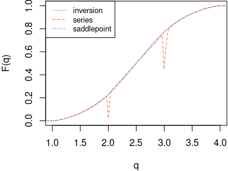

```r
## Graphical comparison
par(mar = c(4, 4, 0.1, 0.1))
plot(qseq, type = "n", xlim = c(1, 4), ylim = c(0, 1),
     xlab = "q", ylab = "F(q)")
lines(qseq, pseq_inv, col = "gray", lty = 1)
lines(qseq, pseq_ser, col = "tomato", lty = 2)
lines(qseq, pseq_spa, col = "slateblue", lty = 3)
legend("topleft", legend = c("inversion", "series", "saddlepoint"),
       col = c("gray", "tomato", "slateblue"), lty = 1:3, cex = 0.8)
```

```r
## Logical vector to exclude q around eigenvalues of A
avoid_evals <- ((qseq %% 1) > 0.05) & ((qseq %% 1) < 0.95)

## Numerical comparison
all.equal(pseq_inv[avoid_evals], pseq_ser[avoid_evals],
          check.attributes = FALSE)
```

```
#> [1] "Mean relative difference: 0.0007499845"
```

```r
all.equal(pseq_inv[avoid_evals], pseq_spa[avoid_evals],
          check.attributes = FALSE)
```

```
#> [1] "Mean relative difference: 0.009893572"
```

Around the eigenvalues of `A`, the series expression is slow to converge; this could partly be mitigated by using larger `m` (default `100`), but that will usually be time-consuming, and evaluation of hypergeometric function may fail regardless (for which a warning is already thrown above). Apart from these points, the series and numerical inversion methods yield very similar values. The saddlepoint approximation yields slightly inaccurate result, but is usually the fastest among these methods.

Next, we compare methods for the probability density:

```r
## Generate p-value sequences
dseq_inv <- dqfr(qseq, A, method = "broda",
                 return_abserr_attr = TRUE)
dseq_ser <- dqfr(qseq, A, method = "hillier",
                 check_convergence = FALSE)
dseq_spa <- dqfr(qseq, A, method = "butler")

## Maximum error in numerical inversion;
## looks small enough
max(attr(dseq_inv, "abserr"))
```

```
#> [1] 8.574178e-07
```

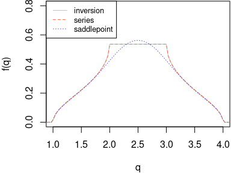

```r
## Graphical comparison
par(mar = c(4, 4, 0.1, 0.1))
plot(qseq, type = "n", xlim = c(1, 4), ylim = c(0, 0.8),
     xlab = "q", ylab = "f(q)")
lines(qseq, dseq_inv, col = "gray", lty = 1)
lines(qseq, dseq_ser, col = "tomato", lty = 2)
lines(qseq, dseq_spa, col = "slateblue", lty = 3)
legend("topleft", legend = c("inversion", "series", "saddlepoint"),
       col = c("gray", "tomato", "slateblue"), lty = 1:3, cex = 0.8)
```

```r
## Numerical comparison
all.equal(dseq_inv, dseq_ser, check.attributes = FALSE)
```

```
#> [1] "Mean relative difference: 8.806696e-07"
```

```r
all.equal(dseq_inv, dseq_spa, check.attributes = FALSE)
```

```
#> [1] "Mean relative difference: 0.05382156"
```

```r
## Do densities sum up to 1?
sum(dseq_inv * diff(qseq)[1])
```

```
#> [1] 1.001194
```

```r
sum(dseq_ser * diff(qseq)[1])
```

```
#> [1] 1.001193
```

```r
sum(dseq_spa * diff(qseq)[1])
```

```
#> [1] 0.9613508
```

The series expression looks successful across the range. The saddlepoint approximation usually fails to capture a fancy profile as seen in the above plot. That will be less of a concern as the dimensionality increases, in which case the distribution approaches normality.

The last three lines conduct a rough check on whether the densities integrate/sum up to unity. The results for the inversion and series methods are expected to approach `1` as we use a finer sequence. The saddlepoint approximation density could be normalized at the cost of slight computational time, although the normalization may or may not yield more accurate results at a particular quantile:

```r
## Normalized saddlepoint approximation density
dseq_spa_normalized <- dqfr(qseq, A, method = "butler",
                            normalize_spa = TRUE)
all.equal(dseq_inv, dseq_spa_normalized,
          check.attributes = FALSE)
```

```
#> [1] "Mean relative difference: 0.05248822"
```

```r
sum(dseq_spa_normalized * diff(qseq)[1])
```

```
#> [1] 1.000244
```

# References

Broda, S. and Paolella, M. S. (2009) Evaluating the density of ratios of noncentral quadratic forms in normal variables. *Computational Statistics and Data Analysis*, **53**, 1264–1270. doi:10.1016/j.csda.2008.10.035.

Butler, R. W. (2007) *Saddlepoint Approximations with Applications*. Cambridge, UK: Cambridge University Press. doi:10.1017/CBO9780511619083.

Butler, R. W. and Paolella, M. S. (2007) Uniform saddlepoint approximations for ratios of quadratic forms. Technical Reports, Department of Statistical Science, Southern Methodist University, no. **351**. [Available on *arXiv* as a preprint.] doi:10.48550/arXiv.0803.2132.

Butler, R. W. and Paolella, M. S. (2008) Uniform saddlepoint approximations for ratios of quadratic forms. *Bernoulli*, **14**, 140–154. doi:10.3150/07-BEJ6169.

Chikuse, Y. (1980) Invariant polynomials with matrix arguments and their applications. *In*: Gupta, R. P., (ed.), *Multivariate Statistical Analysis*. Amsterdam: North-Holland. pp. 53–68.

Chikuse, Y. (1987) Methods for constructing top order invariant polynomials. *Econometric Theory*, **3**, 195–207. doi:10.1017/S026646660001029X.

Davies, R. B. (1973) Numerical inversion of a characteristic function. *Biometrika*, **60**, 415–417. doi:10.1093/biomet/60.2.415.

Davies, R. B. (1980) Algorithm AS 155: The distribution of a linear combination of $\chi^2$ random variables. *Journal of the Royal Statistical Society, Series C: Applied Statistics*, **29**, 323–333. doi:10.2307/2346911.

Davis, A. W. (1980) Invariant polynomials with two matrix arguments, extending the zonal polynomials. *In*: Krishnaiah, P. R., (ed.), *Multivariate Analysis—V*. Amsterdam: North-Holland. pp. 287–299.

Forchini, G. (2002) The exact cumulative distribution function of a ratio of quadratic forms in normal variables, with application to the AR(1) model. *Econometric Theory*, **18**, 823–852. doi:10.1017/s0266466602184015.

Forchini, G. (2005) The distribution of a ratio of quadratic forms in noncentral normal variables. *Communications in Statistics—Theory and Methods*, **34**, 999–1008. doi:10.1081/STA-200056855.

Geary, R. C. (1944) Extension of a theorem by Harald Cramér on the frequency distribution of the quotient of two variables. *Journal of the Royal Statistical Society*, **107**, 56–57. doi:10.1111/j.2397-2335.1944.tb01588.x.

Hillier, G. (2001) The density of a quadratic form in a vector uniformly distributed on the *n*-sphere. *Econometric Theory*, **17**, 1–28. doi:10.1017/S026646660117101X.

Hillier, G., Kan, R. and Wang, X. (2009) Computationally efficient recursions for top-order invariant polynomials with applications. *Econometric Theory*, **25**, 211–242. doi:10.1017/S0266466608090075.

Hillier, G., Kan, R. and Wang, X. (2014) Generating functions and short recursions, with applications to the moments of quadratic forms in noncentral normal vectors. *Econometric Theory*, **30**, 436–473. doi:10.1017/S0266466613000364.

Imhof, J. P. (1961) Computing the distribution of quadratic forms in normal variables. *Biometrika*, **48**, 419–426. doi:10.2307/2332763.

Mathai, A. M. and Provost, S. B. (1992) *Quadratic Forms in Random Variables: Theory and Applications*. New York, New York: Marcel Dekker.

Muirhead, R. J. (1982) *Aspects of Multivariate Statistical Theory*. Hoboken, New Jersey: John Wiley & Sons. doi:10.1002/9780470316559.

Paolella, M. S. (2007) *Intermediate Probability: A Computational Approach*. Chichester, UK: John Wiley & Sons. doi:10.1002/9780470035061.

Stuart, A. and Ord, J. K. (1994) *Kendall’s Advanced Theory of Statistics, Vol. 1: Distribution Theory*, 6th ed. London: Hodder Education. [Reprinted by John Wiley & Sons.]

Watanabe, J. (2023) Exact expressions and numerical evaluation of average evolvability measures for characterizing and comparing **G** matrices. *Journal of Mathematical Biology*, **86**, 95. doi:10.1007/s00285-023-01930-8.